# HW#8

### Последовательность

Дана последовательность целых чисел в виде массива. Определите, можно ли получить строго возрастающую последовательность, удалив из массива не более одного элемента.

Примечание: последовательность a0, a1, ..., an считается строго возрастающей, если a0 < a1 < ... < an. Последовательность, содержащая только один элемент, также считается строго возрастающей.

**Примеры**  
Для последовательности = [1, 3, 2, 1], вывод должен быть решение = False.

В этом массиве нет ни одного элемента, который можно было бы удалить, чтобы получить строго возрастающую последовательность.

Для последовательности = [1, 3, 2] вывод должен быть = True.

Вы можете удалить 3 из массива, чтобы получить строго возрастающую последовательность [1, 2]. Альтернативно можно убрать 2, чтобы получить строго возрастающую последовательность [1, 3].

```
def solution(sequence):
    ...

assert solution([1, 2, 3]) == True
assert solution([1, 2, 1, 2]) == False
assert solution([1, 3, 2, 1]) == False
assert solution([1, 2, 3, 4, 5, 3, 5, 6]) == False
assert solution([40, 50, 60, 10, 20, 30]) == False
```

### Число на против

Рассмотрим целые числа от 0 до n-1, записанные по окружности так, чтобы расстояние между любыми двумя соседними числами было одинаковым (обратите внимание, что 0 и n-1 тоже являются соседними).

Учитывая n и first_number, найдите число, которое написано в радиально противоположной позиции от first_number.

**Примеры**  
Для n = 10 и first_number = 2 вывод должен быть (n, first_number) = 7.

```
def solution(n, f_number):
    ...

assert solution(10, 6) == 1
assert solution(10, 2) == 7
assert solution(10, 4) == 9
```

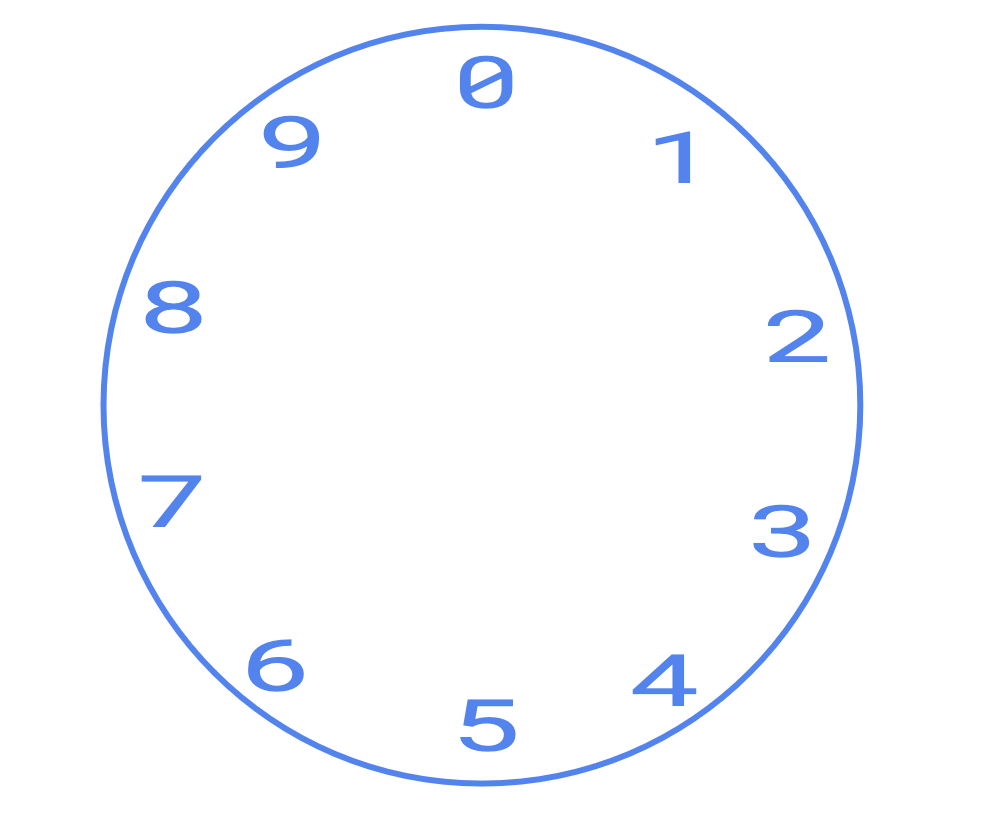

### Validate

Ваша задача написать программу, принимающее число - номер кредитной карты(число может быть четным или не четным). И проверяющей может ли такая карта существовать. Предусмотреть защиту от ввода букв, пустой строки и т.д. Примечания Алгоритм Луна

**Примеры**

```
def solution(number):
    ...

assert solution(4561261212345464) == False
assert solution(4561261212345467) == True
```

*Для проверки:* https://www.paypalobjects.com/en_GB/vhelp/paypalmanager_help/credit_card_numbers.htm